# Analysis of effects of bilateral cortical inactivation on sound localization using logistic regression

Version History:

- Created: 2021-09-11 Stephen Town
- Ported to notebook: 2022-05-16

The individual observations are at the trial level, which is important for analysis of error magnitude, but means that the data for trial accuracy (correct/error) is in binary format.

```r
rm(list = ls())
suppressPackageStartupMessages( library(dplyr))
suppressPackageStartupMessages( library(tidyverse))
suppressPackageStartupMessages( library(lme4))
suppressPackageStartupMessages( library(DHARMa))
```

## 1. Loading and preprocessing

**Load data** from individual subjects and combine.

```r
data_path = '/home/stephen/Github/Vowel_Discrimination_In_Noise/Results/Localization/data/analysis'

magnum <- read_csv( file.path( data_path, 'F1311.csv'), show_col_types = FALSE)
robin <- read_csv( file.path( data_path, 'F1509.csv'), show_col_types = FALSE)

magnum$fNum <- 1311
robin$fNum  <- 1509

df <- rbind(magnum, robin) %>%
  mutate(
    fNum = as.factor(fNum),            # Treat F number as
    HoldTime = HoldTime / 1000         # Convert ms to seconds
    )

df <- subset(df, select=-c(originalFile, SessionDate))       # Remove information about data origin (unless needed for debugging)
df <- subset(df, select=-c(Trial, StartTime, ComputerTime))  # Remove information about trial order (unless needed for debugging)

rm(magnum, robin)
head(df)
```

| CorrectionTrial | CenterReward | SpkrIdx | SpkrPos | duration | HoldTime | Atten | Response | RespTime | Correct | Modality | Condition | LeftTemperature | RightTemperature | fNum | ResponseAngle | Spkr_Rad | spkr_hemifield | resp_hemifield | LatCorrect | Error |
| --- | --- | --- | --- | --- | --- | --- | --- | --- | --- | --- | --- | --- | --- | --- | --- | --- | --- | --- | --- | --- |
| 0 | 0 | 7 | -60 | 250 | 0.901 | 0.0 | 7 | 1068.154 | 1 | Aud | Left | 12 | 36 | 1311 | -60 | -1.0471976 | L | L | 1 | 0 |
| 0 | 0 | 4 | 30 | 250 | 0.601 | 4.5 | 4 | 1085.177 | 1 | Aud | Left | 12 | 35 | 1311 | 30 | 0.5235988 | R | R | 1 | 0 |
| 0 | 0 | 6 | -30 | 250 | 1.001 | 0.0 | 6 | 1101.935 | 1 | Aud | Left | 12 | 35 | 1311 | -30 | -0.5235988 | L | L | 1 | 0 |
| 0 | 0 | 7 | -60 | 250 | 0.651 | 9.0 | 7 | 1122.504 | 1 | Aud | Left | 12 | 35 | 1311 | -60 | -1.0471976 | L | L | 1 | 0 |
| 0 | 0 | 2 | 90 | 250 | 1.001 | 9.0 | 3 | 1223.321 | 0 | Aud | Left | 11 | 35 | 1311 | 60 | 1.5707963 | R | R | 1 | 30 |
| 0 | 0 | 3 | 60 | 250 | 0.801 | 9.0 | 3 | 1247.787 | 1 | Aud | Left | 11 | 35 | 1311 | 60 | 1.0471976 | R | R | 1 | 0 |

Rescale speaker angle and response error from degrees to radians, and remove older ways of encoding sound and response location (in degrees or as index)

```r
df <- df %>%
  mutate(
    SpeakerRad = SpkrPos / 180 * pi,
    ErrorRad = Error / 180 *pi
    ) %>%
  select(-SpkrIdx, -SpkrPos, -Response, -ResponseAngle, Error)

head(df)
```

| CorrectionTrial | CenterReward | duration | HoldTime | Atten | RespTime | Correct | Modality | Condition | LeftTemperature | RightTemperature | fNum | Spkr_Rad | spkr_hemifield | resp_hemifield | LatCorrect | Error | SpeakerRad | ErrorRad |
| --- | --- | --- | --- | --- | --- | --- | --- | --- | --- | --- | --- | --- | --- | --- | --- | --- | --- | --- |
| 0 | 0 | 250 | 0.901 | 0.0 | 1068.154 | 1 | Aud | Left | 12 | 36 | 1311 | -1.0471976 | L | L | 1 | 0 | -1.0471976 | 0.0000000 |
| 0 | 0 | 250 | 0.601 | 4.5 | 1085.177 | 1 | Aud | Left | 12 | 35 | 1311 | 0.5235988 | R | R | 1 | 0 | 0.5235988 | 0.0000000 |
| 0 | 0 | 250 | 1.001 | 0.0 | 1101.935 | 1 | Aud | Left | 12 | 35 | 1311 | -0.5235988 | L | L | 1 | 0 | -0.5235988 | 0.0000000 |
| 0 | 0 | 250 | 0.651 | 9.0 | 1122.504 | 1 | Aud | Left | 12 | 35 | 1311 | -1.0471976 | L | L | 1 | 0 | -1.0471976 | 0.0000000 |
| 0 | 0 | 250 | 1.001 | 9.0 | 1223.321 | 0 | Aud | Left | 11 | 35 | 1311 | 1.5707963 | R | R | 1 | 30 | 1.5707963 | 0.5235988 |
| 0 | 0 | 250 | 0.801 | 9.0 | 1247.787 | 1 | Aud | Left | 11 | 35 | 1311 | 1.0471976 | R | R | 1 | 0 | 1.0471976 | 0.0000000 |

```r
counts = df %>%
  group_by(fNum, Condition, Atten, SpeakerRad, spkr_hemifield, CenterReward) %>%
  summarise(
    nCorrect = sum(Correct),
    nTotal = n(),
    .groups = 'keep'
    ) %>%
  mutate(
    dist_to_midline = abs(SpeakerRad)
  )

bc_counts <- counts[counts$Condition %in% c("Bilateral","Control"),]
```

## 3. Fitting models to test effect of Bilateral cooling on accuracy

### 3.1. Model fitting

Start by doing the logistic regression on performance on full localization. Here, we’re interested in the effect of condition (bilateral cooling or control) on odds of making a correct response. For completeness, we’ll include covariates (signal attenuation, speaker location, center reward) where possible, to try and account for as much variance in the data as possible. Note that there are other variables (Hold Time and sound duration) that we might ideally like to include as further covariates, but these are confounded with subject and so may be the cause of ‘isSingular warnings’.

It’s also important to consider that non-linear relationships may exist between speaker angle and performance. To accommodate this, we will look at a couple of ways of including sound location as part of the model.

Model 1: Ignore speaker completely

```r
BCC_1 = glmer(
  cbind(nCorrect, nTotal - nCorrect) ~ 1 + Condition + Atten + CenterReward + (1|fNum),
  family=binomial,
  data=bc_counts)

summary(BCC_1)
```

```
Generalized linear mixed model fit by maximum likelihood (Laplace Approximation) ['glmerMod']
 Family: binomial  ( logit )
Formula: cbind(nCorrect, nTotal - nCorrect) ~ 1 + Condition + Atten +      CenterReward + (1 | fNum)
   Data: bc_counts

     AIC      BIC   logLik deviance df.resid
   848.8    863.3   -419.4    838.8      129

Scaled residuals:
    Min      1Q  Median      3Q     Max
-5.1226 -0.9735 -0.1285  1.2517  5.7179

Random effects:
 Groups Name        Variance Std.Dev.
 fNum   (Intercept) 0.02171  0.1473
Number of obs: 134, groups:  fNum, 2

Fixed effects:
                  Estimate Std. Error z value Pr(>|z|)
(Intercept)      -0.276803   0.152174  -1.819 0.068913 .
ConditionControl  0.585653   0.108713   5.387 7.16e-08 ***
Atten            -0.035538   0.009659  -3.679 0.000234 ***
CenterReward     -0.493677   0.147620  -3.344 0.000825 ***
---
Signif. codes:  0 ‘***’ 0.001 ‘**’ 0.01 ‘*’ 0.05 ‘.’ 0.1 ‘ ’ 1

Correlation of Fixed Effects:
            (Intr) CndtnC Atten
CondtnCntrl -0.624
Atten       -0.266 -0.031
CenterRewrd -0.063 -0.010  0.015
```

Model 2: Consider model as a random effect

```r
BCC_2 = glmer(
  cbind(nCorrect, nTotal - nCorrect) ~ 1 + Condition + Atten + CenterReward + (1|fNum) + (1|SpeakerRad),
  family=binomial,
  data=bc_counts)

summary(BCC_2)
```

```
Generalized linear mixed model fit by maximum likelihood (Laplace Approximation) ['glmerMod']
 Family: binomial  ( logit )
Formula: cbind(nCorrect, nTotal - nCorrect) ~ 1 + Condition + Atten +      CenterReward + (1 | fNum) + (1 | SpeakerRad)
   Data: bc_counts

     AIC      BIC   logLik deviance df.resid
   752.3    769.7   -370.2    740.3      128

Scaled residuals:
    Min      1Q  Median      3Q     Max
-5.3826 -0.8010 -0.1721  1.1488  4.1365

Random effects:
 Groups     Name        Variance Std.Dev.
 SpeakerRad (Intercept) 0.23171  0.4814
 fNum       (Intercept) 0.07048  0.2655
Number of obs: 134, groups:  SpeakerRad, 7; fNum, 2

Fixed effects:
                  Estimate Std. Error z value Pr(>|z|)
(Intercept)      -0.385321   0.285080  -1.352 0.176495
ConditionControl  0.624949   0.110901   5.635 1.75e-08 ***
Atten            -0.036171   0.009861  -3.668 0.000244 ***
CenterReward     -0.511796   0.149972  -3.413 0.000643 ***
---
Signif. codes:  0 ‘***’ 0.001 ‘**’ 0.01 ‘*’ 0.05 ‘.’ 0.1 ‘ ’ 1

Correlation of Fixed Effects:
            (Intr) CndtnC Atten
CondtnCntrl -0.341
Atten       -0.144 -0.031
CenterRewrd -0.033 -0.013  0.016
```

Model 3: Consider the distance from the midline and hemifield of the speaker, without interaction with cooling

```r
BCC_3 = glmer(
  cbind(nCorrect, nTotal - nCorrect) ~ 1 + Condition + dist_to_midline*spkr_hemifield + Atten + CenterReward + (1|fNum),
  family=binomial,
  data=bc_counts)

summary(BCC_3)
```

```
Generalized linear mixed model fit by maximum likelihood (Laplace Approximation) ['glmerMod']
 Family: binomial  ( logit )
Formula: cbind(nCorrect, nTotal - nCorrect) ~ 1 + Condition + dist_to_midline *      spkr_hemifield + Atten + CenterReward + (1 | fNum)
   Data: bc_counts

     AIC      BIC   logLik deviance df.resid
   732.4    754.8   -358.2    716.4      114

Scaled residuals:
    Min      1Q  Median      3Q     Max
-4.6029 -1.0090 -0.0705  1.2347  5.0179

Random effects:
 Groups Name        Variance Std.Dev.
 fNum   (Intercept) 0.05343  0.2311
Number of obs: 122, groups:  fNum, 2

Fixed effects:
                                Estimate Std. Error z value Pr(>|z|)
(Intercept)                     -0.54766    0.24272  -2.256  0.02405 *
ConditionControl                 0.62937    0.11451   5.496 3.89e-08 ***
dist_to_midline                  0.31316    0.12605   2.484  0.01298 *
spkr_hemifieldR                 -0.10638    0.19918  -0.534  0.59329
Atten                           -0.03074    0.01017  -3.023  0.00251 **
CenterReward                    -0.48172    0.15160  -3.178  0.00149 **
dist_to_midline:spkr_hemifieldR  0.01987    0.17635   0.113  0.91031
---
Signif. codes:  0 ‘***’ 0.001 ‘**’ 0.01 ‘*’ 0.05 ‘.’ 0.1 ‘ ’ 1

Correlation of Fixed Effects:
            (Intr) CndtnC dst_t_ spkr_R Atten  CntrRw
CondtnCntrl -0.415
dist_t_mdln -0.544  0.008
spkr_hmfldR -0.407 -0.011  0.668
Atten       -0.149 -0.032 -0.037 -0.061
CenterRewrd -0.024 -0.016 -0.032 -0.010  0.018
dst_t_md:_R  0.378  0.012 -0.715 -0.929  0.049  0.018
```

Make the model slightly more complex by considering the distance to the midline and hemifield, with an interaction

```r
BCC_4 = glmer(
  cbind(nCorrect, nTotal - nCorrect) ~ 1 + Condition*dist_to_midline + dist_to_midline*spkr_hemifield + Atten + CenterReward + (1|fNum),
  family=binomial,
  data=bc_counts)

summary(BCC_4)
```

```
Generalized linear mixed model fit by maximum likelihood (Laplace Approximation) ['glmerMod']
 Family: binomial  ( logit )
Formula: cbind(nCorrect, nTotal - nCorrect) ~ 1 + Condition * dist_to_midline +      dist_to_midline * spkr_hemifield + Atten + CenterReward +      (1 | fNum)
   Data: bc_counts

     AIC      BIC   logLik deviance df.resid
   722.6    747.8   -352.3    704.6      113

Scaled residuals:
    Min      1Q  Median      3Q     Max
-4.3739 -1.0060  0.0645  1.3835  4.7738

Random effects:
 Groups Name        Variance Std.Dev.
 fNum   (Intercept) 0.05379  0.2319
Number of obs: 122, groups:  fNum, 2

Fixed effects:
                                 Estimate Std. Error z value Pr(>|z|)
(Intercept)                      -1.43421    0.36239  -3.958 7.57e-05 ***
ConditionControl                  1.63770    0.32336   5.065 4.09e-07 ***
dist_to_midline                   1.13315    0.27485   4.123 3.74e-05 ***
spkr_hemifieldR                  -0.11633    0.20046  -0.580 0.561701
Atten                            -0.03047    0.01019  -2.991 0.002781 **
CenterReward                     -0.48613    0.15164  -3.206 0.001346 **
ConditionControl:dist_to_midline -0.93514    0.27666  -3.380 0.000725 ***
dist_to_midline:spkr_hemifieldR   0.02500    0.17687   0.141 0.887617
---
Signif. codes:  0 ‘***’ 0.001 ‘**’ 0.01 ‘*’ 0.05 ‘.’ 0.1 ‘ ’ 1

Correlation of Fixed Effects:
            (Intr) CndtnC dst_t_ spkr_R Atten  CntrRw CnC:__
CondtnCntrl -0.791
dist_t_mdln -0.823  0.831
spkr_hmfldR -0.263 -0.019  0.294
Atten       -0.103 -0.008 -0.013 -0.061
CenterRewrd -0.009 -0.015 -0.024 -0.011  0.018
CndtnCnt:__  0.736 -0.932 -0.888  0.015 -0.004  0.010
dst_t_md:_R  0.248  0.013 -0.321 -0.929  0.049  0.019 -0.009
```

Finally, consider the three way interaction between speaker hemifield, distance to midline and cooling condition

```r
BCC_5 = glmer(
  cbind(nCorrect, nTotal - nCorrect) ~ 1 + Condition*dist_to_midline*spkr_hemifield + Atten + CenterReward + (1|fNum),
  family=binomial,
  data=bc_counts)

summary(BCC_5)
```

```
Generalized linear mixed model fit by maximum likelihood (Laplace Approximation) ['glmerMod']
 Family: binomial  ( logit )
Formula: cbind(nCorrect, nTotal - nCorrect) ~ 1 + Condition * dist_to_midline *      spkr_hemifield + Atten + CenterReward + (1 | fNum)
   Data: bc_counts

     AIC      BIC   logLik deviance df.resid
   693.1    723.9   -335.5    671.1      111

Scaled residuals:
    Min      1Q  Median      3Q     Max
-3.9755 -0.9987 -0.2170  1.3051  4.8403

Random effects:
 Groups Name        Variance Std.Dev.
 fNum   (Intercept) 0.05354  0.2314
Number of obs: 122, groups:  fNum, 2

Fixed effects:
                                                 Estimate Std. Error z value Pr(>|z|)
(Intercept)                                      -3.09152    0.54027  -5.722 1.05e-08 ***
ConditionControl                                  3.48173    0.53608   6.495 8.32e-11 ***
dist_to_midline                                   2.73690    0.43916   6.232 4.60e-10 ***
spkr_hemifieldR                                   2.88770    0.65505   4.408 1.04e-05 ***
Atten                                            -0.03009    0.01024  -2.938 0.003307 **
CenterReward                                     -0.51531    0.15248  -3.380 0.000726 ***
ConditionControl:dist_to_midline                 -2.72537    0.45908  -5.937 2.91e-09 ***
ConditionControl:spkr_hemifieldR                 -3.36667    0.68833  -4.891 1.00e-06 ***
dist_to_midline:spkr_hemifieldR                  -2.89281    0.56437  -5.126 2.96e-07 ***
ConditionControl:dist_to_midline:spkr_hemifieldR  3.28493    0.59479   5.523 3.34e-08 ***
---
Signif. codes:  0 ‘***’ 0.001 ‘**’ 0.01 ‘*’ 0.05 ‘.’ 0.1 ‘ ’ 1

Correlation of Fixed Effects:
            (Intr) CndtnC dst_t_ spkr_R Atten  CntrRw CnC:__ CnC:_R d__:_R
CondtnCntrl -0.910
dist_t_mdln -0.895  0.903
spkr_hmfldR -0.743  0.751  0.739
Atten       -0.062 -0.013 -0.010 -0.030
CenterRewrd  0.012 -0.029 -0.040 -0.026  0.018
CndtnCnt:__  0.856 -0.941 -0.956 -0.706 -0.001  0.033
CndtnCnt:_R  0.708 -0.778 -0.703 -0.951  0.012  0.025  0.733
dst_t_md:_R  0.695 -0.703 -0.778 -0.937  0.018  0.036  0.744  0.891
CndtC:__:_R -0.661  0.726  0.738  0.888 -0.003 -0.034 -0.772 -0.936 -0.949
```

Model comparison

```r
anova(BCC_3, BCC_4, BCC_5)
```

```
Data: bc_counts
Models:
BCC_3: cbind(nCorrect, nTotal - nCorrect) ~ 1 + Condition + dist_to_midline * spkr_hemifield + Atten + CenterReward + (1 | fNum)
BCC_4: cbind(nCorrect, nTotal - nCorrect) ~ 1 + Condition * dist_to_midline + dist_to_midline * spkr_hemifield + Atten + CenterReward + (1 | fNum)
BCC_5: cbind(nCorrect, nTotal - nCorrect) ~ 1 + Condition * dist_to_midline * spkr_hemifield + Atten + CenterReward + (1 | fNum)
      npar    AIC    BIC  logLik deviance  Chisq Df Pr(>Chisq)
BCC_3    8 732.39 754.82 -358.19   716.39
BCC_4    9 722.61 747.85 -352.31   704.61 11.778  1  0.0005992 ***
BCC_5   11 693.06 723.90 -335.53   671.06 33.555  2  5.171e-08 ***
---
Signif. codes:  0 ‘***’ 0.001 ‘**’ 0.01 ‘*’ 0.05 ‘.’ 0.1 ‘ ’ 1
```

### 3.2. Model checking

Checking logistic regression models is difficult because many of the conventional indicators of poor model quality used in linear regression (heteroscedacity, Gaussian distribution of residuals) don’t apply. Here, we’ll use the DHARMa package to calculate randomized quantile residuals using a simulation approach. This hypothesis is that the cumulative distribution of residuals should give average values close to 0.5 and within the bounds of 0.25 to 0.75. We can inspect how residuals differ between conditions to get an idea of where problems might be occuring ()

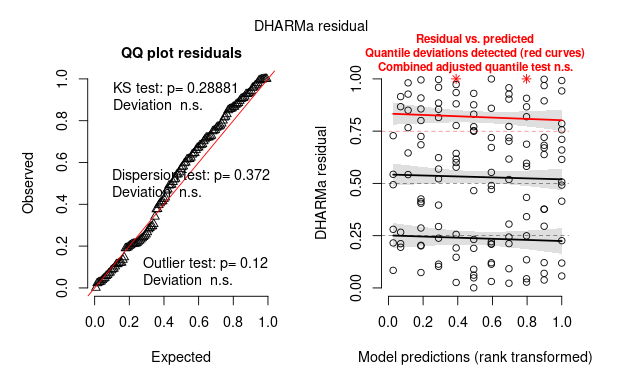

```r
simulationOutput <- simulateResiduals(fittedModel = BCC_2, n=500, plot = T)
```

### 3.3. Model Prediction

Ok, let’s try instead using **model prediction** to see if the process generated by the model matches what we see in the data. We start by adding a column to the input table that consists of the probability of making a correct response according to the model, from which we then estimate the number of correct trials for each type of experimental condition.

```r
# Predict probability of making correct response
bc_counts$fit <- predict(BCC_2, bc_counts, type="response")

# Predict the number of correct trials, using original trial counts
bc_counts <- bc_counts %>%
  mutate(
    predicted_correct = fit * nTotal)

# Summarize data center reward and attenuation
bc_agg = bc_counts %>%
  group_by(fNum, Condition, SpeakerRad) %>%
  summarise(
    nCorrect = sum(nCorrect),
    nTotal = sum(nTotal),
    predicted_correct = sum(predicted_correct),
    .groups = 'keep'
    ) %>%
  mutate(
    pCorrect = nCorrect / nTotal * 100,
    fit_p = predicted_correct / nTotal * 100
  )
```

```r
ggplot(                                 # Plot facet grid for predicted and observed performance
  bc_agg %>%
    mutate(Spkr_deg = SpeakerRad / pi * 180),
  aes(x = Spkr_deg, color=Condition)
  ) +
geom_line(
  aes(y = fit_p)
  ) +
geom_point(
  shape = 19,
  aes(
    y = pCorrect,
    size = nTotal,
    alpha = 0.25
    )
  ) +
scale_size(range = c(0, 4), trans="log10") +
scale_color_manual(
  labels = c("Cooled", "Control"),
  values = c("#37a9a4", "#3d3d3d")
) +
theme(
  axis.text = element_text(size = 7.5),
  axis.title = element_text(size = 8),
  strip.text = element_text(size = 8),
  legend.title = element_text(size=8),
  legend.text = element_text(size=7.5)
  #strip.background = element_rect(colour="black", fill="white")
  ) +
scale_x_continuous(name="Speaker Angle (°)", limits=c(-100, 100), breaks=seq(-90,90,30)) +
scale_y_continuous(name="% Correct", limits=c(0, 100)) +
facet_wrap(. ~fNum)

ggsave(filename = "Localization_predictions_BCC2b.png", width = 12, height = 6, units = "cm", dpi=300)
```

[output not shown]